# Myanmar’s changing conflict geography

Township concentrations, emerging patterns and the limits of reported events

Author

Yufan You

Published

October 8, 2026

**Research question:** Where is recorded armed conflict concentrated in Myanmar, and which township neighbourhoods are becoming more concentrated over time?

The analysis covers **53,899 events** and **89,005 reported fatalities**, from January 2021 to September 2025. It combines local spatial statistics with 19 quarterly observations. A spatial scan then asks where conflict gained a larger share of the national total.

Executive summary · [GitHub project](https://github.com/yufanyou2025/ISS626-VAA/tree/master/Take-home_Ex/Take-home_Ex02)

## 1 Study context and design

Conflict monitoring has to answer two different planning questions. A township with a large accumulated burden may need sustained humanitarian support. A township where the surrounding concentration is increasing may need closer monitoring even if its historical total is smaller. This report keeps those signals separate.

The study follows the [Take-home Exercise 2 brief](https://isss626-ay2026-27aug.netlify.app/take-home_ex02.html). The geographical unit is the township, using **MIMU v9.4**, and the observation period is **1 January 2021–30 September 2025**. The brief’s two references to passenger trips and hexagons are treated as editing errors because its objectives and data specification require Myanmar conflict events and townships.

I use three ACLED event types: **Battles**, **Explosions/Remote violence**, and **Violence against civilians**. This operational definition focuses on armed conflict. It excludes riots, protests and strategic developments, including some events that ACLED classifies under its wider definition of political violence. One coded event is the unit of observation. Several events can share a date and location without being duplicates. Reported fatalities are an additional burden measure, with uncertainty in reporting and estimation.

The questions are:

1. Which townships form high or low clusters, and which contrast with their neighbours?
2. Which neighbourhood concentrations intensify, diminish or appear intermittently?
3. Where did the share of national recorded conflict increase between comparable early and recent windows?

Counts measure the geography of **reported conflict activity**. They do not estimate the probability that an individual experiences harm. No reliable, time-matched population or exposure denominator is supplied.

## 2 Data preparation and quality assessment

### 2.1 Sources and input checks

The original eLearn ACLED CSV contains 87,109 rows and 31 columns. Its dates cover the full study window. No exact duplicate rows or repeated event IDs were found, and dates, coordinates and fatalities have no missing values. Other fields do contain missing entries, so removing every row with any missing field would discard usable events.

The source contains six records labelled **Indian Ocean**, which are excluded by the Myanmar country filter. The latest record-update timestamp is 29 September 2026, 22:19:21 UTC. That field describes a record update, not a documented export date. I accessed the supplied course file on 8 October 2026 and pin its SHA-256 hash for replication.

[MIMU’s GeoNode layer](https://geonode.themimu.info/layers/geonode%3Ammr_polbnda_adm3_250k_mimu_1) contains 330 polygons, all labelled P-code version 9.4. Township P-codes are complete and unique. The original WGS84 geometries are valid. `st_transform()` puts the polygons and event points in a Myanmar-centred Albers equal-area projection, avoiding reliance on a single UTM zone across the country. `st_make_valid()` is a defensive step and does not repair any invalid input polygons in this snapshot.

### 2.2 A sample that reconciles to the input

| Stage | Retained | Excluded |
| --- | --- | --- |
| Original rows | 87109 | 0 |
| Remove exact duplicate rows | 87109 | 0 |
| Myanmar country records | 87103 | 6 |
| Study window: 2021-01-01 to 2025-09-30 | 87103 | 0 |
| Three armed-conflict event types | 54000 | 33103 |
| Finite coordinates within geographic ranges | 54000 | 0 |
| Geographic precision 1 or 2 | 53907 | 93 |
| Unique or admin3-resolved township intersection | 53899 | 8 |

I exclude geographic precision 3 because its coordinates represent a broader administrative area. Precision 2 accounts for **45.1%** of the retained sample. It remains in the main analysis, but its uncertainty matters at township boundaries. A precision 1-only rerun measures the sensitivity to this choice. I do not interpret that subset as complete coverage of actual conflict. ACLED fatality zeros can also reflect the absence of a reported estimate, so they should not all be read as verified zero deaths.

`st_intersects()` assigns points to townships. All retained matches are unique. Eight eligible records lie outside the polygon layer; they remain in a private inspection file and do not enter the counts. No nearest-township snap is applied. Simple normalisation matches the supplied admin3 name with the mapped township for 53,789 records. The other 110 include 102 missing admin3 names and eight different labels. The spatial intersection determines the assignment, with those discrepancies recorded as a limitation rather than silently corrected names.

### 2.3 Balanced time periods and neighbourhoods

`expand_grid()` creates all **330 × 57 = 18,810 township-month combinations**. After joining observed counts, absent combinations become zero **recorded** events. These are not proof of no violence. Aggregation produces **330 × 19 = 6,270 township-quarter combinations**. Both cubes reconcile exactly to the retained event and fatality totals. Using complete quarters avoids treating nine months of 2025 as a full year.

Queen contiguity treats shared edges or vertices as neighbours. A 10 m tolerance is small relative to the source’s 1:250,000 mapping scale and handles minor digitisation gaps. Munaung, Chaungzon and Cocokyun have no Queen neighbours. They remain in descriptive outputs and the full cubes, but the spatial tests use the connected **327-township component**, representing 53,884 events. The three islands account for 15 retained events. Their maps indicate that no spatial test is available. A rook rerun tests the effect of requiring a shared edge.

| check | value |
| --- | --- |
| Township polygons | 330 |
| Unique township P-codes | 330 |
| Invalid before repair | 0 |
| Invalid after repair | 0 |
| Queen graph components | 4 |
| Queen islands | 3 |
| Minimum Queen neighbours (excluding islands) | 1 |
| Maximum Queen neighbours | 11 |
| Complete monthly periods | 57 |
| Complete quarterly periods | 19 |

## 3 The geographical distribution of recorded conflict

### 3.1 Monthly changes

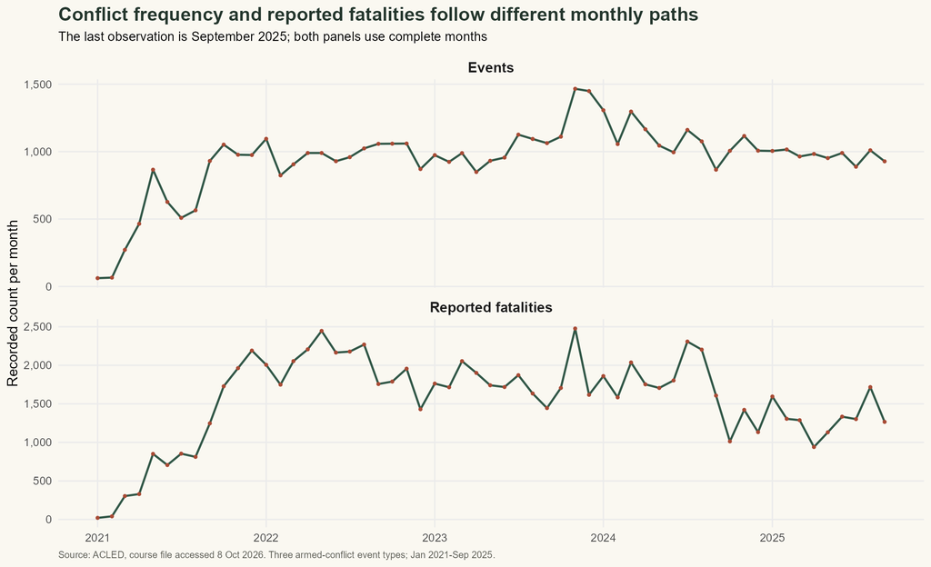

Figure 1: Monthly events and reported fatalities

The largest monthly event count is **1,466 in November 2023**. The two panels show why frequency and reported fatalities should be read separately: a month with many events need not have the highest reported fatality total. All observations are complete months, so the September 2025 endpoint does not introduce a partial-month comparison. Changes may reflect both conflict activity and changes in access to reporting.

### 3.2 Township burden

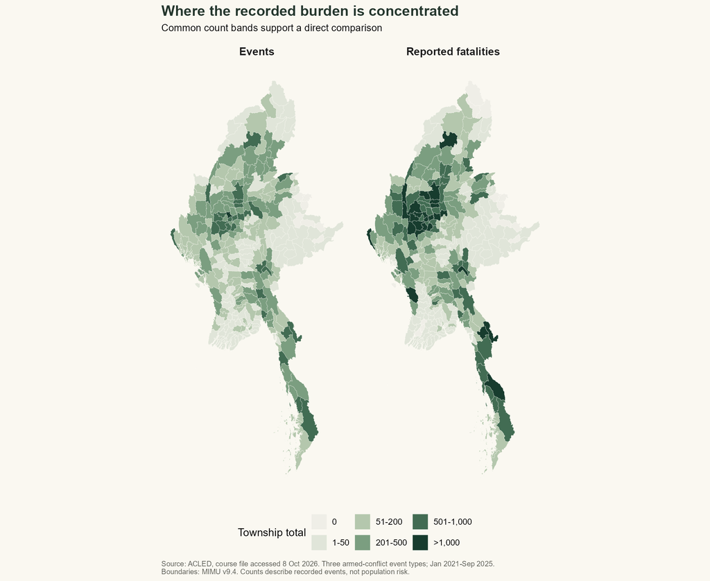

Figure 2: Recorded event and fatality totals by township

**Sagaing** has the largest state/region event total, with 12,612 events. At township level, **Monywa** leads with 1,039 events, while **Kale** has the highest reported fatality total (1,877). The ten townships with the most events account for **15.9%** of the analytical sample. These counts describe an uneven recorded burden. Large polygons are not automatically more dangerous, and unrecorded events remain outside the map.

| Township | State/region | Events | Reported fatalities |
| --- | --- | --- | --- |
| Monywa | Sagaing | 1039 | 1771 |
| Kawkareik | Kayin | 946 | 1524 |
| Myaing | Magway | 934 | 1419 |
| Kale | Sagaing | 886 | 1877 |
| Hpakant | Kachin | 854 | 1262 |
| Shwebo | Sagaing | 806 | 1551 |
| Madaya | Mandalay | 789 | 1117 |
| Nawnghkio | Shan (North) | 788 | 465 |
| Kyaukkyi | Bago (East) | 777 | 705 |
| Yesagyo | Magway | 760 | 1434 |

## 4 Local measures of spatial association

### 4.1 What the tests assess

Global Moran’s I supplies a broad check: **I = 0.488**, with **permutation p = 0.001**. The alternative is positive autocorrelation. The 999 permutations randomly reassign event totals over the fixed township graph. This supports examining local concentrations, but it does not identify their causes.

Local Moran’s I compares a township’s deviation from the mean with its neighbours’ average deviation. Row-standardised Queen weights exclude the township itself. High-high and low-low are clusters; high-low and low-high are spatial outliers. `localmoran_perm()` holds the focal value fixed and permutes neighbour values, without repeated draws within a simulated neighbourhood. Quadrants use the mean-centred variable and its spatial lag, not the sign of I alone.

Getis–Ord Gi* asks whether a neighbourhood sum is unusually high or low. Its weights include the focal township. `localG_perm()` provides conditional permutation inference. I use the alternative-aware **two-sided simulated p-value**, rather than the folded tail probability. All primary LMSA colours require **p < .05**. Benjamini–Hochberg (BH) adjusted values are retained to show the effect of testing many townships. These are exploratory tests of spatially exchangeable values, not a model of population exposure or conflict mechanisms.

### 4.2 Clusters and outliers

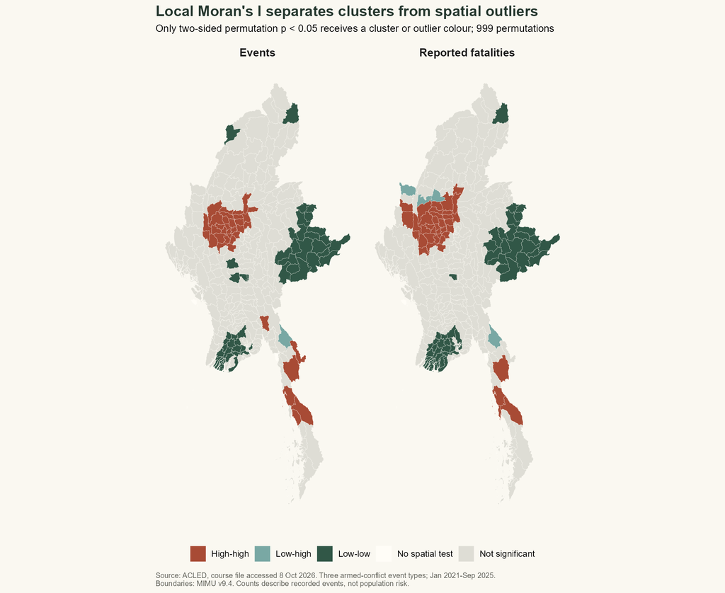

Figure 3: Significant Local Moran clusters and outliers

For events, Local Moran’s I identifies **36 high-high** and **52 low-low** townships. It also flags 0 high-low and 1 low-high outliers. High-low locations deserve a separate reading: they have relatively high counts beside lower-count neighbours, rather than belonging to an extensive high-count cluster. Reported fatalities give a different classification because severity and event frequency do not rank every township identically. Grey areas have insufficient evidence at the chosen threshold, which is different from evidence of no conflict.

| Township | State/region | Events | Class | p | BH q |
| --- | --- | --- | --- | --- | --- |
| Hlaingbwe | Kayin | 61 | Low-high | 0.002 | 0.024 |

### 4.3 Hot and cold neighbourhoods

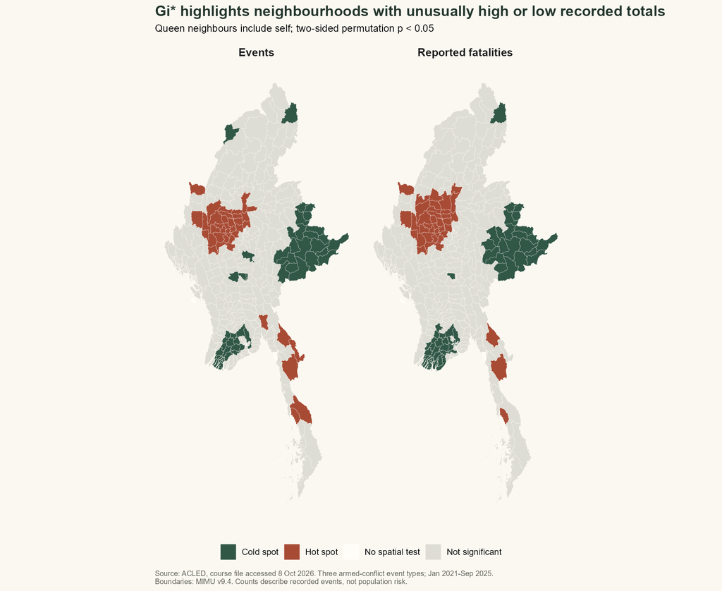

Figure 4: Significant Getis–Ord Gi star neighbourhoods

Gi* identifies **39 event hot spots** and **51 cold spots**. The corresponding fatality analysis identifies 39 hot spots. Gi* includes the focal township, so a significant neighbourhood does not require every member to have a high individual count. A cold spot means a relatively low recorded total under this comparison; it does not establish safety. The apparent certainty also falls when multiple testing is considered, as the table below shows.

| Variable | Local Moran p < .05 | Local Moran BH q < .05 | Gi* p < .05 | Gi* BH q < .05 |
| --- | --- | --- | --- | --- |
| Events | 89 | 44 | 90 | 48 |
| Reported fatalities | 106 | 72 | 105 | 72 |

## 5 Emerging hot spot analysis

### 5.1 Space-time Gi* and Mann–Kendall

`spacetime()` constructs the quarterly cube and checks its balance. I then explicitly build each bin’s neighbourhood from the township and its Queen neighbours in the current and immediately preceding quarter (**k = 1**). The combined space-time weights sum to one. The first quarter has no earlier quarter and therefore a shorter temporal neighbourhood. Its results are an endpoint-sensitive baseline.

`spdep::localG_perm()` computes Gi* on this explicit graph. Standardisation uses the mean and variance across **all 6,213 mainland township-quarter bins**, and conditional permutations hold the focal bin fixed while reassigning other bin values across that space-time reference. I use its alternative-aware two-sided simulated p-value, not its folded tail probability. This differs from sfdep 0.2.5’s classroom routine, which combines quarter-specific standardisation with permutations pooled across periods. A fixed reference makes the interpretation here explicit: high or low concentration relative to the complete observed space-time distribution. National changes in event frequency can therefore contribute to temporal trends. The redistribution scan later conditions on national window totals to address that separate issue.

Mann–Kendall tests the ordered series of **space-time Gi*** at each township. Positive tau means increasing concentration against this fixed reference; it is not a rate of change in event counts.

Classification rules are explicit in `methods.R`: a new class has only its final bin significant in that family; a consecutive class has a final uninterrupted run; intensifying, persistent and diminishing classes require at least 90% of bins in the same family. The trend direction separates intensification from diminution. Sporadic and oscillating classes require a significant final bin; oscillating locations have also experienced the opposite family. Historical classes have at least 90% qualifying earlier bins and a final bin outside that family. These are transparent R adaptations of the [Esri pattern definitions](https://doc.esri.com/en/arcgis-pro/latest/tool-reference/space-time-pattern-mining/learnmoreemerging.html), not a claim to reproduce ArcGIS’s complete FDR implementation.

### 5.2 Patterns with significant temporal evidence

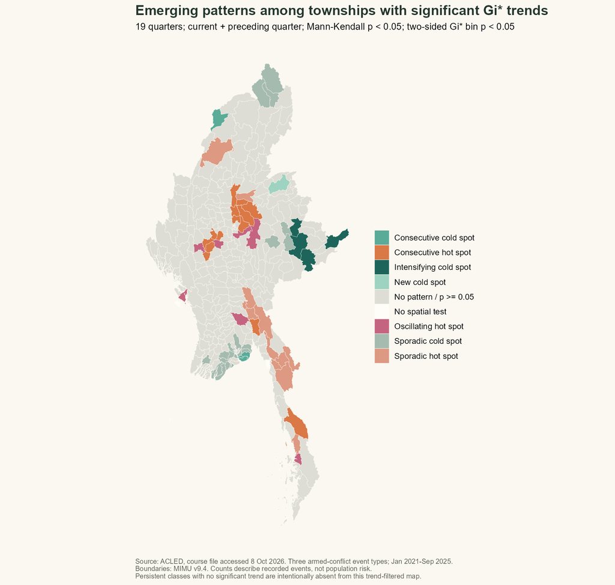

Figure 5: Emerging hot spot classes filtered by significant Mann Kendall trends

**165 of 327 townships** have ordinary Mann–Kendall p < .05; **150** remain after BH adjustment across township trend tests. The map shows classified patterns only where the trend has p < .05. This meets the brief’s significance filter but deliberately omits persistent locations without a significant trend. Their classes remain in the table and downloadable results. Increasing Gi* indicates a rising neighbourhood concentration against the fixed space-time reference. It can reflect national escalation as well as a geographical change, which motivates the separate redistribution scan.

Of the significant trends, **85** also satisfy an EHSA class. A trend alone does not guarantee a hot- or cold-spot pattern under the final-bin and persistence rules.

| Class | All townships | MK p < .05 | MK BH q < .05 |
| --- | --- | --- | --- |
| Consecutive cold spot | 14 | 13 | 13 |
| Consecutive hot spot | 20 | 14 | 13 |
| Intensifying cold spot | 5 | 5 | 5 |
| New cold spot | 2 | 1 | 1 |
| No pattern detected | 188 | 80 | 72 |
| Oscillating cold spot | 1 | 0 | 0 |
| Oscillating hot spot | 8 | 7 | 7 |
| Persistent cold spot | 16 | 0 | 0 |
| Sporadic cold spot | 55 | 33 | 28 |
| Sporadic hot spot | 18 | 12 | 11 |

### 5.3 Reading the histories behind the classes

**Consecutive hot spots.** Fourteen townships in this class also have significant MK trends. The largest event totals include Madaya in Mandalay, Nawnghkio in northern Shan, and Yesagyo in Magway. These locations finish with an uninterrupted run of significant high-concentration quarters. The pattern points to sustained recent pressure across several regions, rather than a single nationwide centre. The run length describes continuity at the quarterly scale; it does not establish uninterrupted daily fighting.

**Sporadic hot spots.** Twelve locations have significant trends, including Kawkareik and Myawaddy in Kayin and Kyaukkyi in eastern Bago. They end as hot spots after an intermittent history, without a significant cold-spot episode. This eastern and southeastern concentration suggests recurring pressure that a cumulative map alone cannot distinguish from continuous concentration. Kawkareik’s history below helps show the difference.

**Oscillating hot spots.** Seven locations combine a significant trend with a final hot bin and an earlier cold episode. Examples include Kyauktaga in eastern Bago, Taungtha in Mandalay and Ramree in Rakhine. Their locations span more than one part of Myanmar. The common feature is a switch in the statistical history, not a claim that they share the same conflict mechanism. Changes in reporting could contribute to those switches.

**Cold-spot patterns.** Significant consecutive and sporadic cold classes are prominent among Yangon townships. The five intensifying cold spots include Lanmadaw and several Shan townships. Matman has zero recorded events in the retained sample. This is especially important for interpretation: a statistically low concentration and a downward Gi* trend cannot demonstrate peace, adequate reporting or low humanitarian need. These patterns require contextual checking before any operational use.

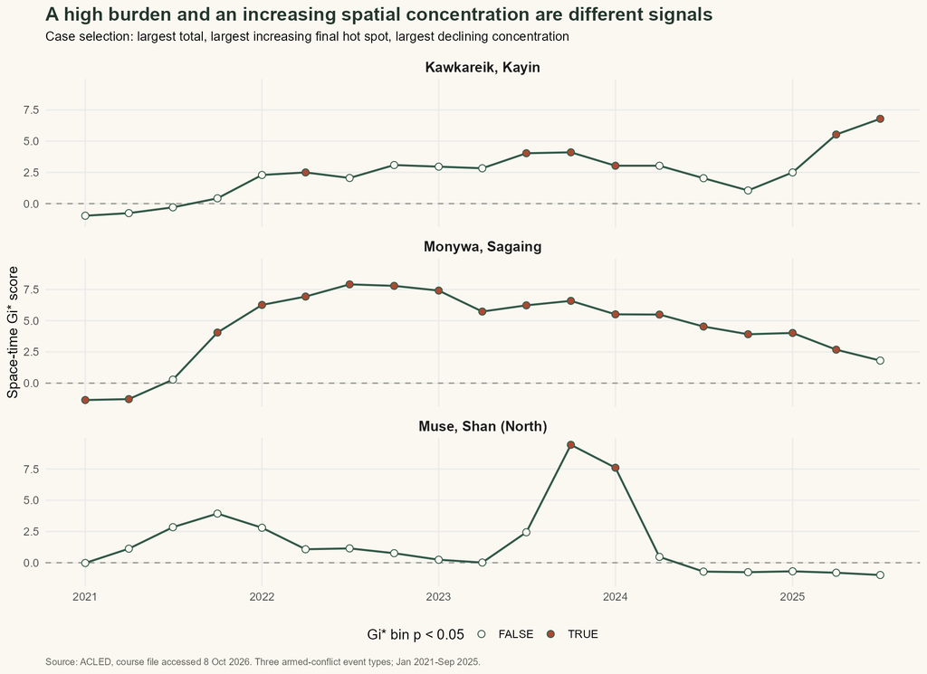

Figure 6: Space time Gi star histories for three selected townships

The cases use explicit selection rules rather than choosing attractive trajectories. They include the largest event total, the largest-burden final hot spot with a significant positive trend, and the largest-burden location with a significant negative trend. Filled points mark significant Gi* bins. Muse’s declining concentration illustrates that a substantial accumulated count can coexist with weak recent hot-spot evidence. Abrupt changes also warn against treating a single monotonic trend as a full account of the conflict’s history.

| Township | State/region | Events | Class | tau | MK p | MK BH q | 2-quarter block p |
| --- | --- | --- | --- | --- | --- | --- | --- |
| Kawkareik | Kayin | 946 | Sporadic hot spot | 0.535 | 0.002 | 0.005 | 0.015 |
| Monywa | Sagaing | 1039 | No pattern detected | -0.135 | 0.441 | 0.545 | 0.577 |
| Muse | Shan (North) | 640 | No pattern detected | -0.427 | 0.012 | 0.030 | 0.049 |

### 5.4 How robust are the patterns?

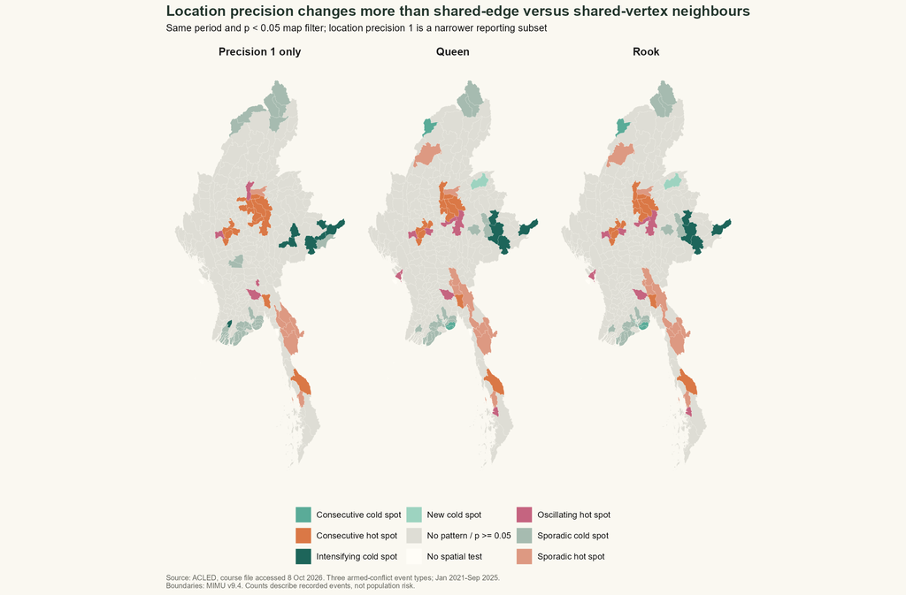

Figure 7: Emerging hot spot maps under alternative neighbourhood and precision choices

Gi* series have median lag-one autocorrelation **0.71**. Temporal neighbourhoods overlap, and ordinary Mann–Kendall assumes independence under its usual null. I therefore shuffle contiguous two-quarter and three-quarter blocks, recomputing the trend score for 999 permutations. The corresponding p < .05 counts are **129** and **114**, compared with 165 under ordinary MK. These block tests preserve dependence inside short blocks, but neither guarantee removal of longer dependence nor account fully for seasonality. They are sensitivity evidence, not a universal correction. Bin-level BH classes are also saved in `ehsa-results.csv`; their adjustment family is all 6,213 mainland quarter bins per specification.

## 6 Value-added analysis: a spatial scan of redistribution

### 6.1 Why the extra method adds a different answer

EHSA concerns neighbourhood concentration through time. The spatial scan asks a narrower comparison: **where did a larger share of national recorded events move between an early and recent window?** I compare January 2021–September 2022 with January 2024–September 2025. Both contain 21 months, with the same calendar-month composition. The intervening period is deliberately omitted from this contrast, while it remains in EHSA.

A Bernoulli spatial scan treats recent events as cases and early events as controls. Circular candidates expand around township interior points, include 1–30 townships, and contain at most 20% of the combined early/recent events. The likelihood ratio compares the recent-event fraction inside a circle with the fraction outside. This conditions on reporting geography rather than using a population denominator. The null randomly reallocates period labels while holding township totals and the national recent-event total fixed. Each of 999 simulations repeats the entire search; the observed statistic is compared with the simulated **maximum**, accounting for the search over circles. At most three non-overlapping clusters are reported. The R implementation follows the [Bernoulli scan likelihood and Monte Carlo logic](https://www.satscan.org/papers/k-cstm1997.pdf); it does not run SaTScan software.

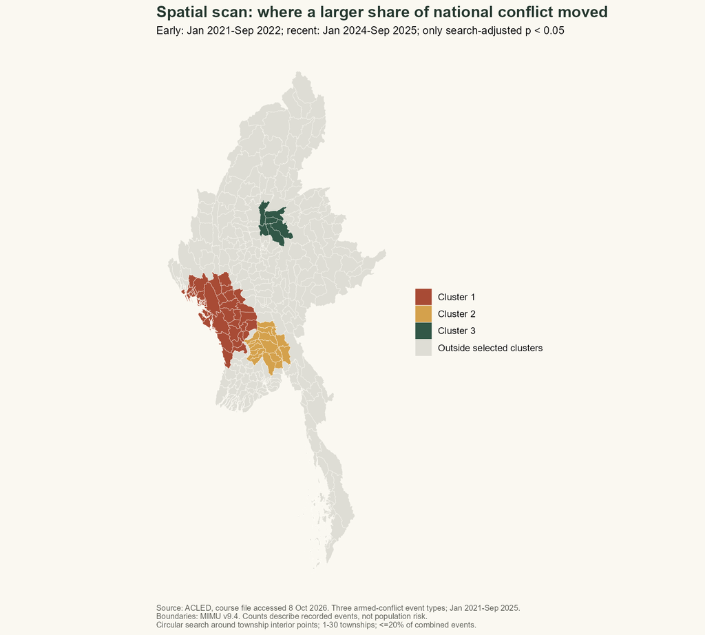

Figure 8: Spatial redistribution clusters with search adjusted significance

The strongest selected cluster is centred on **Ramree**, spans 30 townships, and increases its share from **2.2% to 11.5%**. Its recent-to-early share ratio is **5.19**, with search-adjusted p = **0.001**. This identifies a geographic shift beyond a general national increase. The cluster boundary depends on circular candidates and township representative points; it is not a front line or a forecast. Spatial and temporal dependence between related conflict events may make event-label permutations overconfident, so the scan remains exploratory.

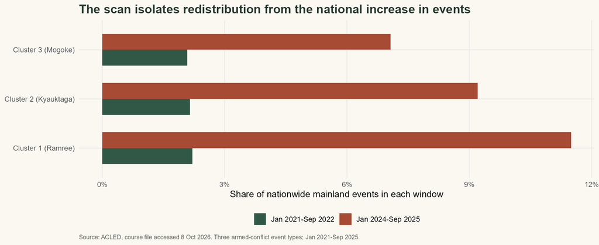

Figure 9: Early and recent national shares for spatial scan clusters

The share comparison makes the scan’s contribution visible. It distinguishes an increase in a cluster’s importance within the national record from an increase that simply follows the countrywide total. The reported groups are non-overlapping, but they do not partition Myanmar and are not ranked aid-allocation recommendations. Differences in reporting access between the two windows could also shift recorded shares.

| Cluster | Centre | Townships | Early events | Recent events | Share ratio | Search-adjusted p |
| --- | --- | --- | --- | --- | --- | --- |
| 1 | Ramree | 30 | 357 | 2509 | 5.194 | 0.001 |
| 2 | Kyauktaga | 18 | 347 | 2009 | 4.279 | 0.001 |
| 3 | Mogoke | 6 | 336 | 1543 | 3.394 | 0.001 |

## 7 Integrated findings and peacebuilding implications

Accumulated counts, local spatial association and temporal change answer different questions. **Monywa has the largest event total but no formal EHSA pattern under the stated rules.** Its burden is still substantial. Kawkareik illustrates a significant increasing concentration, while the scan’s leading group around **Ramree** identifies a shift towards recent events. A single ranking would hide those differences. Reported fatalities add another dimension: they describe estimated severity and can change the priority suggested by event frequency alone.

For humanitarian preparedness, sustained high-burden neighbourhoods support maintaining capacity over time. Significant increasing concentrations suggest locations where field teams could check changing displacement, medical demand and access constraints. High-low outliers call for local verification because a township can stand apart from its immediate surroundings. The analysis does not locate safe travel corridors or justify tactical decisions.

Township labels should start a discussion with local organisations, not settle it. Before reallocating support, combine the statistical evidence with current needs assessments, service capacity, displacement data and operational access. A cold spot may have fewer recorded events because reporting is difficult. Likewise, a diminishing hot spot may still face serious harm despite a declining relative concentration.

## 8 Limitations and what I would improve

- **Reporting and measurement:** ACLED records reported events and uncertain fatality estimates. Access and source coverage can vary geographically and over time. There is no credible population-risk estimate here.
- **Location uncertainty:** precision 2 makes up a substantial part of the sample. The precision 1 rerun changes which events are represented, not just their spatial accuracy. Eight unmatched points and eight conflicting non-missing township labels warrant source-level checking.
- **Scale and boundaries:** the v9.4 layer is held fixed throughout the period. Township aggregation can conceal local variation and does not represent changing territorial control. Border neighbours outside Myanmar are absent from the spatial comparison.
- **Statistical reference:** permutation tests assume exchangeability. Conflict episodes generate related events; overlapping space-time neighbourhoods induce dependence. BH and short-block checks improve transparency but do not establish independent evidence for every coloured township.
- **Design sensitivity:** the first EHSA quarter lacks a lagged period; 19 quarters offer limited trend resolution. Circular scan candidates can miss irregular corridors. The chosen scan windows and maximum cluster size influence the findings.

The most useful next step is to investigate the locations whose conclusions change with event precision, then add displacement or service-access information with a compatible observation period. This would improve the planning interpretation more than adding another map of the same counts.

## 9 Reproducing the analysis

Open the repository’s RStudio project. Download the original eLearn ACLED CSV to `Take-home_Ex/Take-home_Ex02/data/raw/`. The boundary script downloads MIMU v9.4 and checks its content hashes. Install packages recorded in `outputs/package-versions.csv`, then run:

```r
source("Take-home_Ex/Take-home_Ex02/analysis.R", encoding = "UTF-8")
# Or render the report directly; its setup executes the same full workflow:
# quarto render Take-home_Ex/Take-home_Ex02/technical-report.qmd
```

The seed is **6262026** for local tests, EHSA and block checks, and **6262126** for the scan. The local permutation code uses one core. Scripts check input hashes, row reconciliation, keys, cube balance and finite results. The report reads computed outputs for its numerical claims. The slides consume these same results after the report completes. Raw events, event-level intermediates and boundary geometry stay local. Published material contains original analytical figures and statistical summaries, with source attribution. Input access is required to reproduce the analysis.

### 9.1 Executable workflow

The preparation code establishes the study window, records the sample exclusions and builds the cube. The analysis code sets the statistical reference and retains each Gi* series. The scan code implements a separate redistribution question. Figure code uses consistent count bands and neutral fills for non-significant areas. These are the same files called by a normal report render; the folds below display them without executing a second time.

**Read the executable R code: config.R**

```r
# All scripts run from the ISS626-VAA repository root.
ex02 <- "Take-home_Ex/Take-home_Ex02"
config02 <- list(
  start = as.Date("2021-01-01"),
  end = as.Date("2025-09-30"),
  access_date = as.Date("2026-10-08"),
  # Country-centred equal-area projection; Myanmar spans multiple UTM zones.
  crs = "+proj=aea +lat_1=10 +lat_2=28 +lat_0=19 +lon_0=96 +datum=WGS84 +units=m +no_defs",
  # Armed-conflict subset, not a synonym for all ACLED political disorder.
  event_types = c("Battles", "Explosions/Remote violence", "Violence against civilians"),
  spatial_snap_m = 10,
  alpha = .05,
  nsim = 999L,
  seed = 6262026L,
  boundary_url = paste0(
    "https://geonode.themimu.info/geoserver/wfs?service=WFS&version=1.0.0&",
    "request=GetFeature&typeName=geonode%3Ammr_polbnda_adm3_250k_mimu_1&outputFormat=SHAPE-ZIP"),
  boundary_layer = "mmr_polbnda_adm3_250k_mimu_1"
)
```

**Read the executable R code: prepare-boundaries.R**

```r
# Validate the exact MIMU v9.4 input before working with conflict records.
source("Take-home_Ex/Take-home_Ex02/config.R", encoding = "UTF-8")
suppressPackageStartupMessages({
  library(sf)
  library(dplyr)
  library(readr)
})
boundary_dir02 <- file.path(ex02, "data/boundaries")
shape_dir02 <- file.path(boundary_dir02, "mimu-v9.4")
out02 <- file.path(ex02, "outputs")
dir.create(shape_dir02, recursive = TRUE, showWarnings = FALSE)
dir.create(out02, recursive = TRUE, showWarnings = FALSE)
shape02 <- file.path(shape_dir02, paste0(config02$boundary_layer, ".shp"))
if (!file.exists(shape02)) {
  archive02 <- file.path(boundary_dir02, "mimu-v9.4-townships.zip")
  if (!file.exists(archive02))
    download.file(config02$boundary_url, archive02, mode = "wb", method = "libcurl")
  unzip(archive02, exdir = shape_dir02)
}

# ZIP metadata changes with server download time, so pin its content files.
expected02 <- c(
  shp = "7616d353dd931087c36a1356b596e10046de333c2723f315f670025a5b07c0c1",
  dbf = "fabc135fbe34acc0e04c733433aeb0b1edd2dccd976ecec5ce0e73e904a8189f",
  prj = "de5c1395a1ffc517ee2112b217c89595d01a7944eb65374c06547d4771b29167"
)
manifest02 <- tibble(
  file = paste0(config02$boundary_layer, ".", names(expected02)),
  sha256 = vapply(names(expected02), function(ext) {
    digest::digest(file.path(shape_dir02, paste0(config02$boundary_layer, ".", ext)),
                   algo = "sha256", file = TRUE)
  }, character(1)),
  source = config02$boundary_url,
  accessed = as.character(config02$access_date)
)
if (!identical(unname(manifest02$sha256), unname(expected02)))
  stop("MIMU content differs from the validated v9.4 snapshot. Inspect the change before analysis.")
write_csv(manifest02, file.path(out02, "boundary-manifest.csv"))

# English labels and stable P-codes are retained; Myanmar labels are unnecessary
# for the join and are not transliterated or inferred from a console display.
boundary_raw02 <- st_read(shape02, quiet = TRUE)
required02 <- c("TS_PCODE", "TS", "ST", "PCode_V")
stopifnot(all(required02 %in% names(boundary_raw02)),
          nrow(boundary_raw02) == 330L,
          all(boundary_raw02$PCode_V == 9.4),
          !anyNA(boundary_raw02$TS_PCODE),
          !anyDuplicated(boundary_raw02$TS_PCODE),
          !is.na(st_crs(boundary_raw02)),
          st_crs(boundary_raw02)$epsg == 4326)
invalid02 <- sum(!st_is_valid(boundary_raw02))
townships02 <- boundary_raw02 |>
  transmute(township_id = TS_PCODE, township = TS, state = ST) |>
  arrange(township_id) |>
  st_transform(config02$crs) |>
  st_make_valid()
stopifnot(all(st_is_valid(townships02)), !any(st_is_empty(townships02)))

# An island is not silently connected to a distant mainland township.
# A 10 m tolerance addresses tiny digitisation gaps in the 1:250,000 layer.
queen02 <- spdep::poly2nb(townships02, queen = TRUE,
                         snap = config02$spatial_snap_m,
                         row.names = townships02$township_id)
rook02 <- spdep::poly2nb(townships02, queen = FALSE,
                        snap = config02$spatial_snap_m,
                        row.names = townships02$township_id)
components02 <- spdep::n.comp.nb(queen02)
islands02 <- spdep::card(queen02) == 0L
audit02 <- tibble(
  check = c("Township polygons", "Unique township P-codes", "Invalid before repair",
            "Invalid after repair", "Queen graph components", "Queen islands",
            "Minimum Queen neighbours (excluding islands)", "Maximum Queen neighbours",
            "Complete monthly periods", "Complete quarterly periods"),
  value = c(nrow(townships02), n_distinct(townships02$township_id), invalid02,
            sum(!st_is_valid(townships02)), components02$nc, sum(islands02),
            min(spdep::card(queen02)[!islands02]), max(spdep::card(queen02)), 57, 19)
)
write_csv(audit02, file.path(out02, "boundary-audit.csv"))
write_csv(st_drop_geometry(townships02) |>
            mutate(queen_neighbours = spdep::card(queen02),
                   rook_neighbours = spdep::card(rook02),
                   component = components02$comp.id,
                   spatial_island = islands02),
          file.path(out02, "township-neighbour-audit.csv"))
writeLines(capture.output(sessionInfo()), file.path(out02, "boundary-session-info.txt"))
print(audit02)
message("MIMU v9.4 content, geometry and neighbourhood audit complete.")
```

**Read the executable R code: prepare-events.R**

```r
# Read the original eLearn input, audit exclusions, then build balanced cubes.
source("Take-home_Ex/Take-home_Ex02/prepare-boundaries.R", encoding = "UTF-8")
suppressPackageStartupMessages(library(tidyr))
raw_path02 <- file.path(ex02, "data/raw/ACLED_Data_Myanmar_Jan2021-Sep2025.csv")
if (!file.exists(raw_path02))
  stop("Download the assignment ACLED CSV from eLearn to ", raw_path02)
raw_hash02 <- digest::digest(raw_path02, algo = "sha256", file = TRUE)
stopifnot(raw_hash02 == "b0e4a044bdfec7883db11a3e8b92922ed6e4aea949b06cdcbcb872b9ebc1db1a")
raw02 <- read_csv(raw_path02, show_col_types = FALSE,
                  col_types = cols(event_date = col_date(), .default = col_guess()))
stopifnot(all(c("event_id_cnty", "event_date", "country", "event_type", "latitude",
                "longitude", "geo_precision", "time_precision", "fatalities",
                "admin1", "admin3") %in% names(raw02)),
          nrow(problems(raw02)) == 0L)
write_csv(tibble(file = basename(raw_path02), sha256 = raw_hash02,
                 accessed = as.character(config02$access_date),
                 source = "ACLED (Armed Conflict Location & Event Data), eLearn assignment file; https://acleddata.com/"),
          file.path(out02, "event-input-manifest.csv"))
input_summary02 <- tibble(
  measure = c("Input rows", "Columns", "Exact duplicate rows", "Duplicate event IDs",
              "Missing event dates", "Missing coordinates", "Missing fatalities",
              "First event date", "Last event date", "Latest record-update timestamp (UTC)"),
  value = as.character(c(nrow(raw02), ncol(raw02), sum(duplicated(raw02)),
                         sum(duplicated(raw02$event_id_cnty)), sum(is.na(raw02$event_date)),
                         sum(!is.finite(raw02$latitude) | !is.finite(raw02$longitude)),
                         sum(is.na(raw02$fatalities)), as.character(min(raw02$event_date)),
                         as.character(max(raw02$event_date)),
                         format(as.POSIXct(max(raw02$timestamp), origin = "1970-01-01", tz = "UTC")))))
write_csv(input_summary02, file.path(out02, "input-summary.csv"))
stopifnot(!anyNA(raw02$event_date), !anyNA(raw02$event_id_cnty))
events02 <- distinct(raw02)
if (anyDuplicated(events02$event_id_cnty))
  stop("Conflicting repeated event IDs require manual review; no automatic latest-record selection.")
audit_events02 <- tibble(stage = "Original rows", retained = nrow(raw02))
audit_stage02 <- function(label) {
  audit_events02 <<- bind_rows(audit_events02, tibble(stage = label, retained = nrow(events02)))
}
audit_stage02("Remove exact duplicate rows")
events02 <- filter(events02, country == "Myanmar")
audit_stage02("Myanmar country records")
events02 <- filter(events02, between(event_date, config02$start, config02$end))
audit_stage02("Study window: 2021-01-01 to 2025-09-30")
write_csv(count(events02, event_type, name = "events"), file.path(out02, "event-type-audit.csv"))
events02 <- filter(events02, event_type %in% config02$event_types)
audit_stage02("Three armed-conflict event types")
write_csv(count(events02, geo_precision, time_precision, name = "events"),
          file.path(out02, "precision-audit.csv"))
swapped02 <- sum(events02$latitude > 90 & events02$longitude < 90, na.rm = TRUE)
if (swapped02 > 0L) stop("Possible latitude/longitude reversal requires source inspection.")
events02 <- filter(events02, is.finite(latitude), is.finite(longitude),
                    between(latitude, -90, 90), between(longitude, -180, 180))
audit_stage02("Finite coordinates within geographic ranges")
stopifnot(swapped02 == 0L, all(events02$fatalities >= 0), !anyNA(events02$fatalities))
events02 <- filter(events02, geo_precision %in% c(1L, 2L))
audit_stage02("Geographic precision 1 or 2")

# Project points into the same CRS. A boundary point can intersect two polygons.
# Use the supplied admin3 label only to resolve one of those existing matches.
points02 <- st_as_sf(events02, coords = c("longitude", "latitude"), crs = 4326,
                     remove = FALSE) |> st_transform(st_crs(townships02))
matches02 <- st_intersects(points02, townships02)
normal02 <- function(x) gsub("[^a-z0-9]", "", tolower(ifelse(is.na(x), "", x)))
assigned02 <- vapply(seq_along(matches02), function(i) {
  z <- matches02[[i]]
  if (length(z) == 1L) return(z)
  if (length(z) > 1L) {
    exact <- z[normal02(townships02$township[z]) == normal02(events02$admin3[i])]
    if (length(exact) == 1L) return(exact)
  }
  NA_integer_
}, integer(1))
join_audit02 <- tibble(
  category = c("One intersecting township", "No intersecting township",
               "Multiple intersecting townships", "Multiple resolved by admin3", "Unresolved multiple matches"),
  events = c(sum(lengths(matches02) == 1), sum(lengths(matches02) == 0),
             sum(lengths(matches02) > 1), sum(lengths(matches02) > 1 & !is.na(assigned02)),
             sum(lengths(matches02) > 1 & is.na(assigned02))))
write_csv(join_audit02, file.path(out02, "spatial-join-audit.csv"))
# Unmatched events are retained privately for inspection; no nearest-polygon snap.
dir.create(file.path(ex02, "data/processed"), recursive = TRUE, showWarnings = FALSE)
saveRDS(events02[is.na(assigned02), ], file.path(ex02, "data/processed/unmatched-events.rds"))
events02$township_id <- townships02$township_id[assigned02]
events02$mapped_township <- townships02$township[assigned02]
events02 <- filter(events02, !is.na(township_id))
audit_stage02("Unique or admin3-resolved township intersection")
events02 <- mutate(events02,
                    month = as.Date(format(event_date, "%Y-%m-01")),
                    quarter = (as.integer(format(event_date, "%Y")) - 2021L) * 4L +
                      (as.integer(format(event_date, "%m")) - 1L) %/% 3L + 1L)
audit_events02 <- audit_events02 |>
  mutate(excluded_at_stage = lag(retained, default = first(retained)) - retained)
write_csv(audit_events02, file.path(out02, "sample-audit.csv"))
write_csv(events02 |>
            summarise(compared = sum(!is.na(admin3)),
                       equal_after_simple_normalisation = sum(normal02(admin3) == normal02(mapped_township)),
                       different_or_missing = sum(normal02(admin3) != normal02(mapped_township))),
          file.path(out02, "admin-label-audit.csv"))
saveRDS(events02, file.path(ex02, "data/processed/events.rds"))

# The full calendar, including zero recorded counts, defines the cube template.
monthly02 <- expand_grid(month = seq(config02$start, as.Date("2025-09-01"), by = "month"),
                         township_id = townships02$township_id) |>
  left_join(events02 |> group_by(month, township_id) |>
              summarise(events = n(), fatalities = sum(fatalities),
                         precise_events = sum(geo_precision == 1L), .groups = "drop"),
            by = c("month", "township_id")) |>
  mutate(across(c(events, fatalities, precise_events), ~replace_na(.x, 0L)))
quarterly02 <- monthly02 |>
  mutate(quarter = (as.integer(format(month, "%Y")) - 2021L) * 4L +
           (as.integer(format(month, "%m")) - 1L) %/% 3L + 1L) |>
  group_by(quarter, township_id) |>
  summarise(across(c(events, fatalities, precise_events), sum), .groups = "drop") |>
  arrange(quarter, township_id)
totals02 <- events02 |> group_by(township_id) |>
  summarise(events = n(), fatalities = sum(fatalities),
             precise_events = sum(geo_precision == 1L), .groups = "drop")
totals02 <- st_drop_geometry(townships02) |> left_join(totals02, by = "township_id") |>
  mutate(across(c(events, fatalities, precise_events), ~replace_na(.x, 0L)))
stopifnot(nrow(monthly02) == 330L * 57L, nrow(quarterly02) == 330L * 19L,
          !anyDuplicated(monthly02[c("month", "township_id")]),
          !anyDuplicated(quarterly02[c("quarter", "township_id")]),
          sum(monthly02$events) == nrow(events02),
          sum(quarterly02$events) == nrow(events02),
          sum(totals02$fatalities) == sum(events02$fatalities))
write_csv(monthly02, file.path(out02, "monthly-cube.csv"))
write_csv(quarterly02, file.path(out02, "quarterly-cube.csv"))
write_csv(totals02, file.path(out02, "township-totals.csv"))
write_csv(monthly02 |> group_by(month) |>
            summarise(events = sum(events), fatalities = sum(fatalities), .groups = "drop"),
          file.path(out02, "national-monthly.csv"))
write_csv(events02 |> count(event_type, name = "events"), file.path(out02, "analytical-event-types.csv"))
message("Sample audit and balanced 57-month / 19-quarter cubes complete.")
print(audit_events02)
```

**Read the executable R code: methods.R**

```r
# Small transparent helpers, shared by the analysis and its verification.
classify_ehsa02 <- function(gi, p, tau, trend_p, alpha = .05) {
  # Separate bin and trend tests, require the correct sign for each family,
  # and require the final bin for consecutive/sporadic/oscillating classes.
  hot <- gi > 0 & p < alpha
  cold <- gi < 0 & p < alpha
  n <- length(gi)
  classify_family <- function(hit, other, label, direction) {
    proportion <- mean(hit)
    if (!hit[n] && proportion >= .9) return(paste("Historical", label))
    if (proportion >= .9) {
      if (trend_p < alpha && tau * direction > 0) return(paste("Intensifying", label))
      if (trend_p < alpha && tau * direction < 0) return(paste("Diminishing", label))
      return(paste("Persistent", label))
    }
    if (!hit[n]) return(NULL)
    if (sum(hit) == 1L) return(paste("New", label))
    run <- rle(rev(hit))$lengths[1]
    if (run >= 2L && sum(hit) == run) return(paste("Consecutive", label))
    if (any(other)) return(paste("Oscillating", label))
    return(paste("Sporadic", label))
  }
  h <- classify_family(hot, cold, "hot spot", 1)
  if (!is.null(h)) return(h)
  c <- classify_family(cold, hot, "cold spot", -1)
  if (!is.null(c)) return(c)
  "No pattern detected"
}

mk02 <- function(x) {
  r <- Kendall::MannKendall(x)
  c(tau = as.numeric(r$tau), p_value = as.numeric(r$sl))
}

block_trend02 <- function(x, block = 2L, nsim = 999L, seed = 6262026L) {
  # Exploratory sensitivity: shuffle contiguous blocks rather than quarters.
  # This preserves short within-block dependence, not seasonality or all lags.
  n <- length(x)
  blocks <- split(seq_len(n), ceiling(seq_len(n) / block))
  score <- function(z) sum(sign(outer(z, z, "-")[lower.tri(matrix(0, n, n))]))
  observed <- score(x)
  set.seed(seed)
  simulated <- replicate(nsim, score(x[unlist(blocks[sample.int(length(blocks))])]))
  (1 + sum(abs(simulated) >= abs(observed))) / (nsim + 1)
}
```

**Read the executable R code: analysis.R**

```r
# Full core workflow. Executed by the technical report in a fresh R process.
source("Take-home_Ex/Take-home_Ex02/prepare-events.R", encoding = "UTF-8")
source("Take-home_Ex/Take-home_Ex02/methods.R", encoding = "UTF-8")
suppressPackageStartupMessages({ library(sfdep); library(ggplot2) })
spdep::set.coresOption(1L)
fig02 <- file.path(ex02, "figures")
dir.create(fig02, recursive = TRUE, showWarnings = FALSE)

# Three genuine islands remain in descriptive tables and in the full cube.
# Spatial inference uses the connected 327-township mainland component.
inference02 <- townships02[!islands02, ]
nb02 <- subset(queen02, !islands02)
nb_rook02 <- subset(rook02, !islands02)
stopifnot(all(spdep::card(nb02) > 0), all(spdep::card(nb_rook02) > 0),
          spdep::n.comp.nb(nb02)$nc == 1L)
lw02 <- spdep::nb2listw(nb02, style = "W")
tot_inference02 <- totals02[match(inference02$township_id, totals02$township_id), ]
stopifnot(identical(tot_inference02$township_id, inference02$township_id))

run_local02 <- function(x, nb, variable, spec) {
  lw <- spdep::nb2listw(nb, style = "W")
  set.seed(config02$seed)
  moran <- spdep::localmoran_perm(x, lw, nsim = config02$nsim,
                                  alternative = "two.sided", iseed = config02$seed,
                                  no_repeat_in_row = TRUE)
  z <- x - mean(x)
  lag_z <- spdep::lag.listw(lw, z)
  # Column 6 is the alternative-aware simulated p, not the folded tail (col 7).
  p <- moran[, 6]
  gi_nb <- spdep::include.self(nb)
  gi_wt <- spdep::nb2listw(gi_nb, style = "W")
  gi <- spdep::localG_perm(x, gi_wt, nsim = config02$nsim,
                           alternative = "two.sided", iseed = config02$seed,
                           no_repeat_in_row = TRUE)
  gi_result <- attr(gi, "internals")
  gi_p <- gi_result[, "Pr(z != E(Gi)) Sim"]
  tibble(township_id = inference02$township_id, variable = variable, specification = spec,
         value = x, local_i = moran[, 1], moran_p = p, moran_q = p.adjust(p, "BH"),
         quadrant = case_when(z > 0 & lag_z > 0 ~ "High-high", z < 0 & lag_z < 0 ~ "Low-low",
                              z > 0 & lag_z < 0 ~ "High-low", TRUE ~ "Low-high"),
         gi_star = as.numeric(gi), gi_p = gi_p, gi_q = p.adjust(gi_p, "BH")) |>
    mutate(lisa_class = if_else(moran_p < .05, quadrant, "Not significant"),
           gi_class = case_when(gi_p >= .05 ~ "Not significant", gi_star > 0 ~ "Hot spot", TRUE ~ "Cold spot"))
}
local02 <- bind_rows(
  run_local02(tot_inference02$events, nb02, "Events", "Queen"),
  run_local02(tot_inference02$fatalities, nb02, "Reported fatalities", "Queen"),
  run_local02(tot_inference02$events, nb_rook02, "Events", "Rook"),
  run_local02(tot_inference02$precise_events, nb02, "Events", "Precision 1 only"))
stopifnot(nrow(local02) == 327L * 4L, all(is.finite(local02$gi_star)),
          all(between(local02$moran_p, 0, 1)), all(between(local02$gi_p, 0, 1)))
write_csv(local02, file.path(out02, "local-results.csv"))
set.seed(config02$seed)
global02 <- spdep::moran.mc(tot_inference02$events, lw02, nsim = config02$nsim,
                            alternative = "greater")
write_csv(tibble(statistic = as.numeric(global02$statistic), p_value = global02$p.value,
                 nsim = config02$nsim), file.path(out02, "global-moran.csv"))
write_csv(local02 |> group_by(variable, specification) |>
            summarise(lisa_p05 = sum(moran_p < .05), lisa_bh05 = sum(moran_q < .05),
                       gi_p05 = sum(gi_p < .05), gi_bh05 = sum(gi_q < .05), .groups = "drop"),
          file.path(out02, "local-significance.csv"))

# Build an explicit space-time graph and use spdep's Gi* implementation.
# Standardisation uses all mainland township-quarter bins as the reference.
# The conditional null holds the focal bin fixed and permutes other bin values.
# This is deliberately distinct from sfdep 0.2.5's slice-standardised routine.
run_ehsa02 <- function(nb, spec, count_column = "events") {
  q <- quarterly02 |> filter(township_id %in% inference02$township_id) |>
    arrange(quarter, township_id)
  cube <- sfdep::spacetime(q, inference02, .loc_col = "township_id", .time_col = "quarter")
  stopifnot(sfdep::is_spacetime_cube(cube), nrow(cube) == 327L * 19L)
  self_nb <- spdep::include.self(nb)
  n_loc <- nrow(inference02)
  graph <- lapply(seq_len(nrow(q)), function(index) {
    time <- (index - 1L) %/% n_loc
    location <- (index - 1L) %% n_loc + 1L
    current <- self_nb[[location]] + time * n_loc
    previous <- if (time > 0L) self_nb[[location]] + (time - 1L) * n_loc else integer()
    as.integer(sort(c(current, previous)))
  })
  class(graph) <- "nb"
  attr(graph, "region.id") <- paste(q$township_id, q$quarter, sep = "_")
  attr(graph, "sym") <- FALSE
  attr(graph, "self.included") <- TRUE
  lw <- spdep::nb2listw(graph, style = "W")
  stopifnot(all(vapply(seq_along(graph), function(i) i %in% graph[[i]], logical(1))),
            all(lengths(graph) > 1))
  set.seed(config02$seed)
  message("Space-time permutations: ", spec)
  gi <- spdep::localG_perm(q[[count_column]], lw, nsim = config02$nsim,
                           alternative = "two.sided", iseed = config02$seed,
                           no_repeat_in_row = TRUE)
  internals <- attr(gi, "internals")
  bins <- q |> select(quarter, township_id, events, fatalities) |>
    mutate(gi_star = as.numeric(gi), p_two = internals[, "Pr(z != E(Gi)) Sim"],
           q_bh = p.adjust(p_two, "BH"), specification = spec)
  trends <- bind_rows(lapply(split(bins, bins$township_id), function(d) {
    d <- arrange(d, quarter)
    mk <- mk02(d$gi_star)
    tibble(township_id = d$township_id[1], tau = mk[["tau"]], trend_p = mk[["p_value"]],
           hot_quarters = sum(d$gi_star > 0 & d$p_two < .05),
           cold_quarters = sum(d$gi_star < 0 & d$p_two < .05),
           final_gi = tail(d$gi_star, 1), final_bin_p = tail(d$p_two, 1),
           classification = classify_ehsa02(d$gi_star, d$p_two, mk[["tau"]], mk[["p_value"]]),
           bh_bin_class = classify_ehsa02(d$gi_star, d$q_bh, mk[["tau"]], mk[["p_value"]]))
  })) |>
    mutate(trend_q = p.adjust(trend_p, "BH"), specification = spec)
  list(bins = bins, trends = trends)
}
base_ehsa02 <- run_ehsa02(nb02, "Queen")
rook_ehsa02 <- run_ehsa02(nb_rook02, "Rook")
precision_ehsa02 <- run_ehsa02(nb02, "Precision 1 only", "precise_events")
bins02 <- bind_rows(base_ehsa02$bins, rook_ehsa02$bins, precision_ehsa02$bins)
ehsa02 <- bind_rows(base_ehsa02$trends, rook_ehsa02$trends, precision_ehsa02$trends)
stopifnot(nrow(bins02) == 327L * 19L * 3L, !anyNA(ehsa02$classification),
          all(is.finite(bins02$gi_star)), all(between(bins02$p_two, 0, 1)))
write_csv(bins02, file.path(out02, "space-time-gistar.csv"))
write_csv(ehsa02, file.path(out02, "ehsa-results.csv"))
write_csv(ehsa02 |> count(specification, classification, name = "townships"),
          file.path(out02, "ehsa-class-counts.csv"))

# Block permutations assess how much ordinary MK evidence relies on treating
# adjacent quarters as exchangeable. They remain sensitivity checks, not a
# guaranteed correction for every source of serial dependence.
message("Trend block sensitivity")
blocks02 <- bind_rows(lapply(split(base_ehsa02$bins, base_ehsa02$bins$township_id), function(d) {
  d <- arrange(d, quarter)
  tibble(township_id = d$township_id[1],
         lag1 = as.numeric(acf(d$gi_star, plot = FALSE, lag.max = 1)$acf[2]),
         block2_p = block_trend02(d$gi_star, 2L, seed = config02$seed),
         block3_p = block_trend02(d$gi_star, 3L, seed = config02$seed))
})) |>
  mutate(block2_q = p.adjust(block2_p, "BH"), block3_q = p.adjust(block3_p, "BH"))
write_csv(blocks02, file.path(out02, "trend-block-sensitivity.csv"))
saveRDS(list(townships = townships02, inference = inference02, totals = totals02,
             local = local02, bins = bins02, ehsa = ehsa02, blocks = blocks02),
        file.path(ex02, "data/processed/core-results.rds"))
source(file.path(ex02, "scan.R"), encoding = "UTF-8")
source(file.path(ex02, "visualise.R"), encoding = "UTF-8")
# Direct attribution travels with downloadable analytical data files.
attribution02 <- "ACLED (Armed Conflict Location & Event Data), course file accessed 2026-10-08; https://acleddata.com/; original township/time aggregation and statistics"
for (file in c("monthly-cube.csv", "quarterly-cube.csv", "township-totals.csv",
               "national-monthly.csv", "analytical-event-types.csv", "local-results.csv",
               "space-time-gistar.csv", "ehsa-results.csv", "redistribution-scan.csv")) {
  table <- read_csv(file.path(out02, file), show_col_types = FALSE)
  table$source <- attribution02
  write_csv(table, file.path(out02, file))
}
writeLines(capture.output(sessionInfo()), file.path(out02, "session-info.txt"))
packages02 <- c("sf", "sfdep", "spdep", "dplyr", "tidyr", "readr", "ggplot2", "Kendall", "digest", "knitr")
write_csv(tibble(package = packages02,
                 version = vapply(packages02, function(p) as.character(packageVersion(p)), character(1))),
          file.path(out02, "package-versions.csv"))
message("Take-home 2 analysis and figures complete.")
```

**Read the executable R code: scan.R**

```r
# Value-added question: where did the national share of recorded conflict move?
# Bernoulli spatial scan: equal 21-month early/recent windows, conditional on
# both the township totals and the nationwide number of recent events.
# This tests geographic redistribution, not a causal change or population risk.
early02 <- events02 |> filter(event_date <= as.Date("2022-09-30")) |> count(township_id)
recent02 <- events02 |> filter(event_date >= as.Date("2024-01-01")) |> count(township_id)
scan_data02 <- st_drop_geometry(inference02) |>
  left_join(rename(early02, early = n), by = "township_id") |>
  left_join(rename(recent02, recent = n), by = "township_id") |>
  mutate(across(c(early, recent), ~replace_na(.x, 0L)), total = early + recent)
sites02 <- st_point_on_surface(inference02)
dist02 <- as.matrix(st_distance(sites02)) / 1000
candidates02 <- list()
candidate_centres02 <- integer()
candidate_radii02 <- numeric()
for (centre in seq_len(nrow(inference02))) {
  order02 <- order(dist02[centre, ], inference02$township_id)
  for (size in 1:30) {
    members <- order02[seq_len(size)]
    mass <- sum(scan_data02$total[members])
    if (mass > 0 && mass <= .2 * sum(scan_data02$total)) {
      candidates02[[length(candidates02) + 1L]] <- members
      candidate_centres02 <- c(candidate_centres02, centre)
      candidate_radii02 <- c(candidate_radii02, max(dist02[centre, members]))
    }
  }
}
# Deduplicate identical circles' membership so the search is reproducible.
keys02 <- vapply(candidates02, function(z) paste(sort(z), collapse = ","), character(1))
unique02 <- !duplicated(keys02)
candidates02 <- candidates02[unique02]
candidate_centres02 <- candidate_centres02[unique02]
candidate_radii02 <- candidate_radii02[unique02]
A02 <- Matrix::sparseMatrix(i = rep(seq_along(candidates02), lengths(candidates02)),
                            j = unlist(candidates02), x = 1,
                            dims = c(length(candidates02), nrow(inference02)))
inside_n02 <- as.numeric(A02 %*% scan_data02$total)
total_n02 <- sum(scan_data02$total)
recent_n02 <- sum(scan_data02$recent)
base_p02 <- recent_n02 / total_n02
term02 <- function(a, b) ifelse(a > 0, a * log(pmax(a, 1e-100) / b), 0)
llr02 <- function(inside_recent) {
  inside_old <- inside_n02 - inside_recent
  outside_recent <- recent_n02 - inside_recent
  outside_old <- total_n02 - inside_n02 - outside_recent
  out <- term02(inside_recent, inside_n02 * base_p02) +
    term02(inside_old, inside_n02 * (1 - base_p02)) +
    term02(outside_recent, (total_n02 - inside_n02) * base_p02) +
    term02(outside_old, (total_n02 - inside_n02) * (1 - base_p02))
  ifelse(inside_recent / inside_n02 > base_p02, out, 0)
}
observed_recent02 <- as.numeric(A02 %*% scan_data02$recent)
observed_llr02 <- llr02(observed_recent02)
draw_labels02 <- function() {
  left_recent <- recent_n02
  left_total <- total_n02
  draw <- integer(nrow(inference02))
  for (i in seq_len(length(draw) - 1L)) {
    draw[i] <- rhyper(1, left_recent, left_total - left_recent, scan_data02$total[i])
    left_recent <- left_recent - draw[i]
    left_total <- left_total - scan_data02$total[i]
  }
  draw[length(draw)] <- left_recent
  stopifnot(sum(draw) == recent_n02, all(draw <= scan_data02$total))
  draw
}
set.seed(config02$seed + 100L)
message("Spatial redistribution scan: ", length(candidates02), " candidate circles")
null_max02 <- replicate(config02$nsim,
                        max(llr02(as.numeric(A02 %*% draw_labels02()))))
# Report at most three non-overlapping candidates. Each p-value compares with
# the maximum from the entire search, not a single preselected circle.
selected02 <- integer()
used02 <- integer()
for (j in order(observed_llr02, decreasing = TRUE)) {
  if (!any(candidates02[[j]] %in% used02)) {
    selected02 <- c(selected02, j)
    used02 <- c(used02, candidates02[[j]])
  }
  if (length(selected02) == 3L) break
}
scan_results02 <- bind_rows(lapply(seq_along(selected02), function(rank) {
  j <- selected02[rank]
  z <- candidates02[[j]]
  inside_recent <- observed_recent02[j]
  inside_early <- inside_n02[j] - inside_recent
  tibble(cluster = rank, centre = scan_data02$township[candidate_centres02[j]],
         radius_km = candidate_radii02[j], townships = length(z),
         early_events = inside_early, recent_events = inside_recent,
         early_share = inside_early / (total_n02 - recent_n02),
         recent_share = inside_recent / recent_n02,
         share_ratio = (inside_recent / recent_n02) / (inside_early / (total_n02 - recent_n02)),
         llr = observed_llr02[j],
         search_adjusted_p = (1 + sum(null_max02 >= observed_llr02[j])) / (config02$nsim + 1),
         members = paste(scan_data02$township[z], collapse = "; "))
}))
write_csv(scan_results02, file.path(out02, "redistribution-scan.csv"))
write_csv(tibble(simulation = seq_along(null_max02), maximum_llr = null_max02),
          file.path(out02, "scan-null-maxima.csv"))
write_csv(tibble(early_window = "2021-01-01 to 2022-09-30", recent_window = "2024-01-01 to 2025-09-30",
                 early_events = total_n02 - recent_n02, recent_events = recent_n02,
                 candidate_circles = length(candidates02), max_townships = 30,
                 maximum_combined_event_share = .2, simulations = config02$nsim,
                 seed = config02$seed + 100L), file.path(out02, "scan-design.csv"))
scan_membership02 <- rep("Outside selected clusters", nrow(inference02))
for (rank in seq_along(selected02)) {
  if (scan_results02$search_adjusted_p[rank] < .05)
    scan_membership02[candidates02[[selected02[rank]]]] <- paste("Cluster", rank)
}
```

**Read the executable R code: visualise.R**

```r
# Analytical figures use static raster maps; no geometry is embedded online.
forest02 <- "#315747"
copper02 <- "#a84b35"
paper02 <- "#faf8f1"
grey02 <- "#deddd5"
source02 <- "Source: ACLED, course file accessed 8 Oct 2026. Three armed-conflict event types; Jan 2021-Sep 2025."
map_source02 <- paste(source02, "Boundaries: MIMU v9.4. Counts describe recorded events, not population risk.", sep = "\n")
theme02 <- theme_minimal(base_size = 12, base_family = "sans") +
  theme(plot.background = element_rect(fill = paper02, colour = NA),
        panel.background = element_rect(fill = paper02, colour = NA),
        plot.title = element_text(face = "bold", size = 16, colour = "#24362d"),
        plot.subtitle = element_text(size = 11, margin = margin(b = 10)),
        plot.caption = element_text(size = 8, hjust = 0, colour = "#55564e"),
        panel.grid.minor = element_blank(), legend.position = "bottom",
        strip.text = element_text(face = "bold", size = 12))
map_theme02 <- theme02 + theme(axis.title = element_blank(), axis.text = element_blank(),
                               axis.ticks = element_blank(), panel.grid = element_blank())
save_plot02 <- function(name, p, width = 11, height = 7) {
  ggsave(file.path(fig02, paste0(name, ".png")), p, width = width, height = height,
         dpi = 180, bg = paper02, limitsize = FALSE)
  slide_p <- p + labs(title = NULL, subtitle = NULL, caption = NULL) +
    theme(text = element_text(size = 20), axis.text = element_text(size = 17),
          strip.text = element_text(size = 20), legend.text = element_text(size = 18),
          legend.title = element_text(size = 18), plot.margin = margin(6, 6, 6, 6))
  # Keep map axes absent when overriding the global text size.
  if (grepl("map|sensitivity", name))
    slide_p <- slide_p + theme(axis.text = element_blank(), axis.ticks = element_blank())
  ggsave(file.path(fig02, paste0("slide-", name, ".png")), slide_p,
         width = width, height = if (height > 8) 7.5 else height,
         dpi = 180, bg = paper02, limitsize = FALSE)
}

monthly_total02 <- monthly02 |> group_by(month) |>
  summarise(Events = sum(events), `Reported fatalities` = sum(fatalities), .groups = "drop") |>
  pivot_longer(-month, names_to = "measure", values_to = "count")
p <- ggplot(monthly_total02, aes(month, count)) +
  geom_line(colour = forest02, linewidth = .85) +
  geom_point(size = .9, colour = copper02) +
  facet_wrap(~measure, ncol = 1, scales = "free_y") +
  scale_x_date(date_breaks = "1 year", date_labels = "%Y") +
  scale_y_continuous(labels = scales::comma) +
  labs(title = "Conflict frequency and reported fatalities follow different monthly paths",
       subtitle = "The last observation is September 2025; both panels use complete months",
       x = NULL, y = "Recorded count per month", caption = source02) + theme02
save_plot02("monthly-pattern", p, height = 6.7)

burden02 <- townships02 |> left_join(totals02 |> select(township_id, events, fatalities), by = "township_id") |>
  pivot_longer(c(events, fatalities), names_to = "measure", values_to = "count") |>
  mutate(measure = recode(measure, events = "Events", fatalities = "Reported fatalities"),
         band = cut(count, breaks = c(-1, 0, 50, 200, 500, 1000, Inf),
                    labels = c("0", "1-50", "51-200", "201-500", "501-1,000", ">1,000")))
p <- ggplot(burden02) + geom_sf(aes(fill = band), colour = "#fffdf7", linewidth = .07) +
  facet_wrap(~measure, nrow = 1) +
  scale_fill_manual(values = c("#efeee7", "#e0e5d9", "#b4c7ad", "#7b9e80", "#426c53", "#173c2e"),
                    drop = FALSE, name = "Township total") +
  labs(title = "Where the recorded burden is concentrated", subtitle = "Common count bands support a direct comparison",
       caption = map_source02) + map_theme02
save_plot02("burden-maps", p, height = 9)

lisa_map02 <- townships02 |> left_join(local02 |> filter(specification == "Queen") |>
                                       select(township_id, variable, lisa_class), by = "township_id",
                                     relationship = "one-to-many") |>
  mutate(lisa_class = replace_na(lisa_class, "No spatial test"))
# Replicate island geometries across facets without implying an inferred class.
main_lisa02 <- filter(lisa_map02, !is.na(variable))
island_lisa02 <- bind_rows(lapply(c("Events", "Reported fatalities"), function(v)
  townships02[islands02, ] |> mutate(variable = v, lisa_class = "No spatial test")))
lisa_map02 <- bind_rows(main_lisa02, island_lisa02)
lisa_colours02 <- c("High-high" = copper02, "Low-low" = forest02,
                     "High-low" = "#d6a44c", "Low-high" = "#79a8a4",
                     "Not significant" = grey02, "No spatial test" = "#fffdf7")
p <- ggplot(lisa_map02) + geom_sf(aes(fill = lisa_class), colour = "#fffdf7", linewidth = .07) +
  facet_wrap(~variable, nrow = 1) + scale_fill_manual(values = lisa_colours02, name = NULL) +
  labs(title = "Local Moran's I separates clusters from spatial outliers",
       subtitle = "Only two-sided permutation p < 0.05 receives a cluster or outlier colour; 999 permutations",
       caption = map_source02) + map_theme02
save_plot02("lisa-maps", p, height = 9)

gi_map02 <- bind_rows(lapply(c("Events", "Reported fatalities"), function(v) {
  townships02 |> left_join(local02 |> filter(specification == "Queen", variable == v) |>
                            select(township_id, gi_class, gi_q, gi_star), by = "township_id") |>
    mutate(variable = v, gi_class = replace_na(gi_class, "No spatial test"))
}))
gi_colours02 <- c("Hot spot" = copper02, "Cold spot" = forest02,
                   "Not significant" = grey02, "No spatial test" = "#fffdf7")
p <- ggplot(gi_map02) + geom_sf(aes(fill = gi_class), colour = "#fffdf7", linewidth = .07) +
  facet_wrap(~variable, nrow = 1) + scale_fill_manual(values = gi_colours02, name = NULL) +
  labs(title = "Gi* highlights neighbourhoods with unusually high or low recorded totals",
       subtitle = "Queen neighbours include self; two-sided permutation p < 0.05",
       caption = map_source02) + map_theme02
save_plot02("gistar-maps", p, height = 9)
```

```r
ehsa_colours02 <- c("New hot spot" = "#e9b04f", "Consecutive hot spot" = "#da7846",
                     "Intensifying hot spot" = "#a72e28", "Persistent hot spot" = "#742a28",
                     "Diminishing hot spot" = "#be866b", "Sporadic hot spot" = "#dd9982",
                     "Oscillating hot spot" = "#c56480", "Historical hot spot" = "#a49388",
                     "New cold spot" = "#9dd3c0", "Consecutive cold spot" = "#5aab98",
                     "Intensifying cold spot" = "#1d655a", "Persistent cold spot" = "#23433f",
                     "Diminishing cold spot" = "#72a59d", "Sporadic cold spot" = "#a6bbb0",
                     "Oscillating cold spot" = "#637d9b", "Historical cold spot" = "#9ba9a7",
                     "No pattern / p >= 0.05" = grey02, "No spatial test" = "#fffdf7")
ehsa_map02 <- bind_rows(lapply(c("Queen", "Rook", "Precision 1 only"), function(spec) {
  townships02 |> left_join(ehsa02 |> filter(specification == spec), by = "township_id") |>
    mutate(specification = spec,
           map_class = case_when(is.na(trend_p) ~ "No spatial test",
                                 trend_p >= .05 | classification == "No pattern detected" ~ "No pattern / p >= 0.05",
                                 TRUE ~ classification))
}))
p <- ggplot(filter(ehsa_map02, specification == "Queen")) +
  geom_sf(aes(fill = map_class), colour = "#fffdf7", linewidth = .1) +
  scale_fill_manual(values = ehsa_colours02, name = NULL) +
  labs(title = "Emerging patterns among townships with significant Gi* trends",
       subtitle = "19 quarters; current + preceding quarter; Mann-Kendall p < 0.05; two-sided Gi* bin p < 0.05",
       caption = paste(map_source02, "Persistent classes with no significant trend are intentionally absent from this trend-filtered map.", sep = "\n")) +
  map_theme02 + theme(legend.position = "right")
save_plot02("ehsa-map", p, width = 10, height = 9.5)

p <- ggplot(ehsa_map02) + geom_sf(aes(fill = map_class), colour = "#fffdf7", linewidth = .04) +
  facet_wrap(~specification, nrow = 1) + scale_fill_manual(values = ehsa_colours02, name = NULL) +
  labs(title = "Location precision changes more than shared-edge versus shared-vertex neighbours",
       subtitle = "Same period and p < 0.05 map filter; location precision 1 is a narrower reporting subset",
       caption = map_source02) + map_theme02 +
  guides(fill = guide_legend(nrow = 3))
save_plot02("ehsa-sensitivity", p, width = 14, height = 9.2)

# Select case histories by explicit rules: the largest event total, plus the
# highest-burden positive-trend final hot spot and negative-trend location.
base_trends02 <- base_ehsa02$trends |> left_join(tot_inference02, by = "township_id")
choose_case02 <- function(d) { if (nrow(d)) head(arrange(d, desc(events)), 1)$township_id else character() }
cases02 <- unique(c(choose_case02(base_trends02),
                    choose_case02(filter(base_trends02, tau > 0, trend_p < .05, final_gi > 0, final_bin_p < .05)),
                    choose_case02(filter(base_trends02, tau < 0, trend_p < .05))))
if (length(cases02) < 3L)
  cases02 <- unique(c(cases02, head(arrange(base_trends02, desc(abs(tau)))$township_id, 3)))[1:3]
case_series02 <- base_ehsa02$bins |> filter(township_id %in% cases02) |>
  left_join(st_drop_geometry(inference02), by = "township_id") |>
  mutate(period = as.Date(paste0(2021 + (quarter - 1) %/% 4, "-",
                                sprintf("%02d", ((quarter - 1) %% 4) * 3 + 1), "-01")),
         significant = p_two < .05,
         label = paste(township, state, sep = ", "))
p <- ggplot(case_series02, aes(period, gi_star)) +
  geom_hline(yintercept = 0, colour = "#99998d", linetype = "dashed") +
  geom_line(colour = forest02, linewidth = .8) +
  geom_point(aes(fill = significant), shape = 21, colour = forest02, size = 2.5) +
  scale_fill_manual(values = c("TRUE" = copper02, "FALSE" = paper02), name = "Gi* bin p < 0.05") +
  facet_wrap(~label, ncol = 1) + scale_x_date(date_breaks = "1 year", date_labels = "%Y") +
  labs(title = "A high burden and an increasing spatial concentration are different signals",
       subtitle = "Case selection: largest total, largest increasing final hot spot, largest declining concentration",
       x = NULL, y = "Space-time Gi* score", caption = source02) + theme02
save_plot02("case-histories", p, height = 8)
write_csv(base_trends02 |> filter(township_id %in% cases02) |>
            left_join(blocks02, by = "township_id"), file.path(out02, "case-townships.csv"))

scan_map02 <- inference02 |> mutate(cluster = scan_membership02)
p <- ggplot(scan_map02) + geom_sf(aes(fill = cluster), colour = "#fffdf7", linewidth = .1) +
  scale_fill_manual(values = c("Cluster 1" = copper02, "Cluster 2" = "#d4a14c",
                              "Cluster 3" = forest02, "Outside selected clusters" = grey02), name = NULL) +
  labs(title = "Spatial scan: where a larger share of national conflict moved",
       subtitle = "Early: Jan 2021-Sep 2022; recent: Jan 2024-Sep 2025; only search-adjusted p < 0.05",
       caption = paste(map_source02, "Circular search around township interior points; 1-30 townships; <=20% of combined events.", sep = "\n")) +
  map_theme02 + theme(legend.position = "right")
save_plot02("redistribution-map", p, width = 10, height = 9)
p <- scan_results02 |> select(cluster, centre, early_share, recent_share) |>
  pivot_longer(c(early_share, recent_share), names_to = "window", values_to = "share") |>
  mutate(window = recode(window, early_share = "Jan 2021-Sep 2022", recent_share = "Jan 2024-Sep 2025"),
         label = paste0("Cluster ", cluster, " (", centre, ")")) |>
  ggplot(aes(label, share, fill = window)) + geom_col(position = "dodge", width = .65) +
  coord_flip() + scale_y_continuous(labels = scales::label_percent(accuracy = 1)) +
  scale_fill_manual(values = c(forest02, copper02), name = NULL) +
  labs(title = "The scan isolates redistribution from the national increase in events",
       x = NULL, y = "Share of nationwide mainland events in each window", caption = source02) + theme02
save_plot02("redistribution-shares", p, height = 4.5)
```

```r
# Results objects for prose and slides: all reported quantities are computed.
summary02 <- list(
  input = nrow(raw02), analytical_events = nrow(events02), fatalities = sum(events02$fatalities),
  precise_events = sum(events02$geo_precision == 1L),
  zero_townships = sum(totals02$events == 0),
  mainland_events = sum(tot_inference02$events),
  island_events = sum(totals02$events[totals02$township_id %in% townships02$township_id[islands02]]),
  global_i = as.numeric(global02$statistic), global_p = global02$p.value,
  top_townships = head(arrange(totals02, desc(events)), 10),
  top_fatalities = head(arrange(totals02, desc(fatalities)), 10),
  top10_share = sum(head(sort(totals02$events, decreasing = TRUE), 10)) / nrow(events02),
  state_totals = totals02 |> group_by(state) |> summarise(events = sum(events), fatalities = sum(fatalities), .groups = "drop") |> arrange(desc(events)),
  peak_month = monthly_total02 |> filter(measure == "Events") |> arrange(desc(count)) |> head(1),
  local_counts = local02 |> filter(specification == "Queen") |> count(variable, lisa_class),
  gi_counts = local02 |> filter(specification == "Queen") |> count(variable, gi_class),
  trend_significant = sum(base_ehsa02$trends$trend_p < .05),
  trend_bh = sum(base_ehsa02$trends$trend_q < .05),
  block2_significant = sum(blocks02$block2_p < .05),
  block3_significant = sum(blocks02$block3_p < .05),
  median_lag1 = median(blocks02$lag1),
  rook_class_agreement = mean(base_ehsa02$trends$classification == rook_ehsa02$trends$classification),
  precision_class_agreement = mean(base_ehsa02$trends$classification == precision_ehsa02$trends$classification),
  ehsa_counts = count(base_ehsa02$trends, classification),
  scan = scan_results02,
  cases = read_csv(file.path(out02, "case-townships.csv"), show_col_types = FALSE)
)
saveRDS(summary02, file.path(out02, "report-results.rds"))
jsonlite::write_json(summary02, file.path(out02, "report-results.json"), pretty = TRUE, auto_unbox = TRUE)
```

## 10 References

- ACLED. [Codebook](https://acleddata.com/sites/default/files/wp-content-archive/uploads/2024/09/ACLED-Codebook-2024.pdf), 3 October 2024. Myanmar course dataset accessed 8 October 2026; filtered to the stated dates and three event types, spatially aggregated to townships and time periods.
- Raleigh, C., Kishi, R., & Linke, A. (2023). Political instability patterns are obscured by conflict dataset scope conditions, sources, and coding choices. *Humanities and Social Sciences Communications*. [doi:10.1057/s41599-023-01559-4](https://doi.org/10.1057/s41599-023-01559-4).
- Myanmar Information Management Unit. [Myanmar Township Boundaries MIMU v9.4](https://geonode.themimu.info/layers/geonode%3Ammr_polbnda_adm3_250k_mimu_1), published 18 June 2023, accessed 8 October 2026. Boundaries and names do not imply official endorsement or acceptance by the United Nations. [Terms](https://themimu.info/mimu-terms-conditions).
- Anselin, L. (1995). Local indicators of spatial association—LISA. *Geographical Analysis*, 27, 93–115. [doi:10.1111/j.1538-4632.1995.tb00338.x](https://doi.org/10.1111/j.1538-4632.1995.tb00338.x).
- Bivand, R. & contributors. [spdep Local Moran documentation](https://r-spatial.github.io/spdep/reference/localmoran.html) and [local G/G* documentation](https://r-spatial.github.io/spdep/reference/localG.html). Installed versions recorded with the outputs.
- Parry, J. & Locke, D. H. [sfdep documentation](https://sfdep.josiahparry.com/). Version 0.2.5 supplies the cube structure; its Gi* reference was inspected when choosing the explicit spdep space-time implementation.
- Esri. [How Emerging Hot Spot Analysis works](https://doc.esri.com/en/arcgis-pro/latest/tool-reference/space-time-pattern-mining/learnmoreemerging.html). Pattern definitions adapted explicitly in R.
- Kulldorff, M. (1997). A spatial scan statistic. *Communications in Statistics—Theory and Methods*, 26, 1481–1496. [Original paper](https://www.satscan.org/papers/k-cstm1997.pdf).
- McLeod, A. I. [Kendall R package](https://cran.r-project.org/package=Kendall). Mann–Kendall implementation and time-series assumptions.

The [Khant Min Naing](https://is415-geospatial-with-khant.netlify.app/take-home_ex/take-home_ex02/take-home_ex02.html) and [Matthew Ho](https://is415-gaa-matthew-ho.netlify.app/takehomeex/takehomeex2/the2.html) submissions informed the organisation and explanation of the workflow. This study uses its own Myanmar inputs, analytical decisions and computed results.